# Understanding US Flight Delays: What Makes Flights Late?

## An Analysis of 2025 Airline On-Time Performance Data

## by Luis Feliu

## Investigation Overview

This presentation communicates the key findings from an exploratory analysis of **7,001,619 US domestic scheduled flights in 2025**. The data comes from the Bureau of Transportation Statistics (BTS) Reporting Carrier On-Time Performance database. The guiding theme is: **which operational, timing, seasonal, and geographic patterns explain whether flights arrive late or recover time?**

**Five guiding questions and key insights:**

1. **Do flights recover after departure?** Completed flights usually make up delay minutes after departure; the median arrival-minus-departure delay is -7 minutes
2. **Which delay causes matter most?** Late-arriving aircraft and carrier-controlled operational delays are the largest attributed causes, with airspace/airport-flow delays also substantial
3. **When is delay risk highest?** Sunday evening is the highest-risk timing window
4. **How does risk change by season?** June/July lead the year, with a separate December spike
5. **Where do recovery patterns differ?** Origin states and territories differ, but state/territory aggregation is coarse

Together, these insights show that delay risk is shaped most by operational reliability, airspace constraints, and schedule timing, while flights often recover some time between departure and arrival.

## Dataset Overview

- **Source:** Bureau of Transportation Statistics (BTS) Reporting Carrier On-Time Performance Data
- **Coverage:** US domestic scheduled flights in 2025
- **Scope:** 7,001,619 scheduled flights; 6,879,484 completed flights used for delay analysis
- **Local data:** monthly source ZIP files in `data/raw/`; optional ignored cache in `data/processed/combined_2025.csv`

The analysis focuses on whether flights arrive late, what causes attributed delay minutes, and when flights recover time after departure. If the saved output reports the processed cache as the source, that reflects the local cache path used for faster reruns; a clean checkout without the cache loads from the committed monthly ZIP files.

## Analysis Fields

| Field group | Used for |
| --- | --- |
| `DepDelay`, `ArrDelay`, `DelayDelta` | Schedule deviation and recovery |
| `DepDel15`, `ArrDel15` | Official 15+ minute delay rates |
| `CarrierDelay`, `WeatherDelay`, `NASDelay`, `SecurityDelay`, `LateAircraftDelay` | Attributed delay causes |
| `Month`, `DayOfWeek`, `CRSDepTime`, `OriginState` | Seasonal, timing, and geographic patterns |

**Note:** Cancelled and diverted flights are excluded from delay analysis because they do not have comparable completed-flight arrival outcomes. Blank delay-cause fields are treated as 0 minutes.

## Insight 1: Flights Often Recover Time After Departure

**Question:** Do late departures get worse or better during the flight?

**Answer:** The typical completed flight **recovers time** after departure. Recovery means the flight arrives with fewer delay minutes than it had at departure. In this dataset, the median change from departure delay to arrival delay is -7 minutes, and the median remains negative across departure-delay ranges. Larger departure delays are still riskier because outcomes become more variable as the initial delay grows.

The visualization below groups flights by departure-delay range and plots the median change in delay from departure to arrival. The shaded band shows the middle 50% of outcomes, split around the zero line: blue indicates recovery, and red indicates delay compounding.

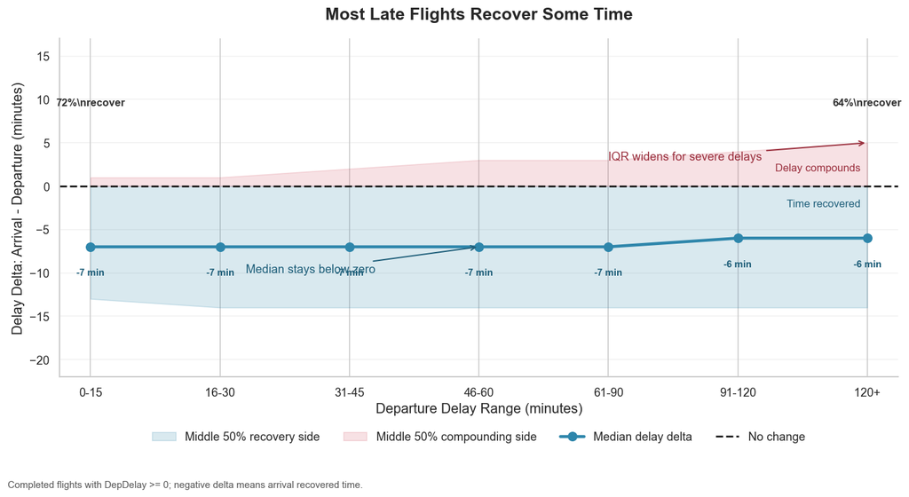

## Insight 2: Late Aircraft and Carrier Delays Lead

**Question:** Which attributed delay causes contribute the most to completed-flight delay minutes?

**Answer:** **Late-arriving aircraft delays** (late inbound aircraft cascading into later departures) and **carrier-controlled operational delays** (crew scheduling, maintenance, and related airline operations) are the two largest contributors when averaged across completed flights. **National Airspace System delays** are also meaningful, so the story is not only airline-controlled; weather and security delays are much smaller in the annual completed-flight average.

This points to two major improvement paths: airline operational reliability through better turnaround, crew management, and planning, plus system-level airspace and airport-flow coordination.

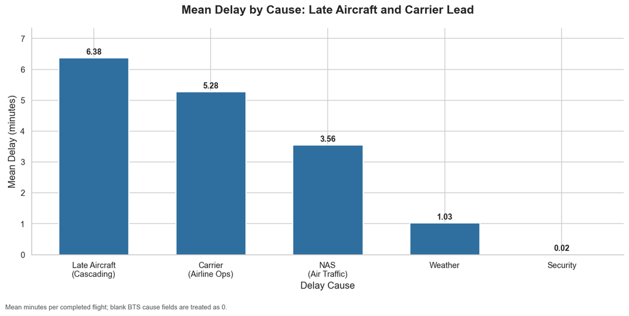

## Insight 3: Sunday Evening Is the Highest-Risk Window

**Question:** Are certain days and departure times associated with more significant arrival delays?

**Answer:** Yes, delay risk rises through the day and peaks on **Sunday evening**. Tuesday is consistently lower-risk, while Thursday and Friday evenings are also elevated but do not exceed Sunday evening.

For travelers, timing matters: morning departures and Tuesday flights generally carry lower risk than late-day Sunday departures.

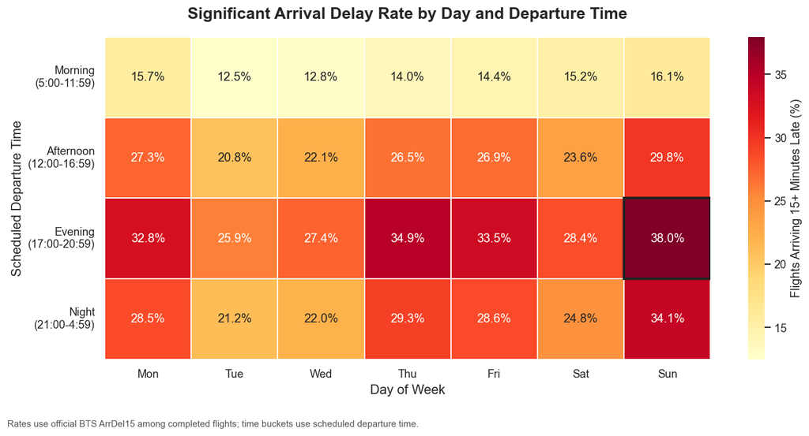

## Insight 4: Seasonality Peaks in Summer and December

**Question:** Are there seasonal patterns in significant arrival delays?

**Answer:** Yes, the strongest delay rates occur in **June and July**, followed by a separate **December** spike. September is the clearest low-delay month. This is more specific than a broad winter-versus-summer story: the 2025 data shows a pronounced summer peak and a holiday/weather spike in December.

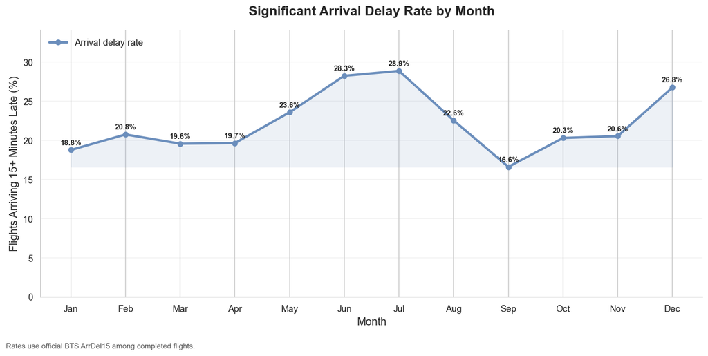

## Insight 5: Geography Matters, but State/Territory Aggregation Is Coarse

**Question:** Do some origins show larger departure-to-arrival recovery gaps than others?

**Answer:** Yes, origin states and territories differ in how much delay changes between departure and arrival. However, the largest gaps are mostly recovery gaps, meaning average arrival delay is lower than average departure delay. This view is a recovery-gap screen rather than a ranking of the worst-delay states. State-level aggregation is useful for screening geographic patterns, but airport- or route-level analysis would be needed for operational decisions.

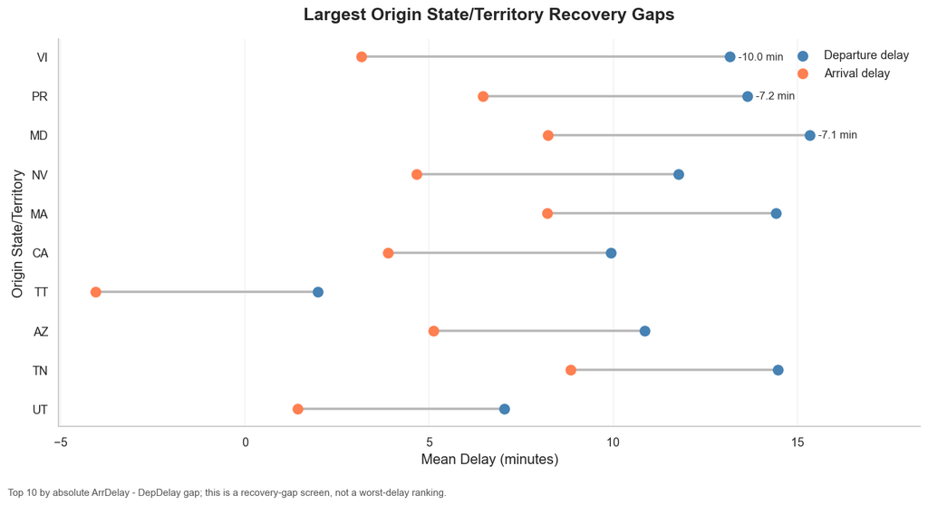

## Summary and Key Takeaways

**Five insights from 7,001,619 scheduled flights:**

1. **Flights often recover time**: completed flights usually make up delay minutes after departure
2. **Late aircraft and carrier-controlled delays lead**: they are the largest attributed contributors, with airspace/airport-flow delay also meaningful
3. **Sunday evening is highest risk**: delay risk rises through the day, with Thursday and Friday evenings also elevated
4. **Seasonality peaks in summer and December**: June/July lead the year, September is lowest, and December is the main winter spike
5. **Geography matters, but coarsely**: origin states and territories show different recovery gaps, but airport and route context would be needed for decisions

**Bottom line:** Departure delay remains the strongest signal for arrival delay, but completed flights often make up some delay minutes en route. The clearest levers for reducing delay risk are airline operational reliability, airspace/airport coordination, and schedule planning around high-risk time windows and seasons.

**For travelers:** Choose morning departures when possible, treat Sunday evening as the riskiest window, and be especially cautious during the June/July summer peak and December holiday/weather spike.